## EDA Case Study: Business Analytics for FMCG company

### Background: A large FMCG company has presence in PAN India. The company owns variety of brands in 3 business lines-Ice-Creams, Cakes-Biscuits and Chocolates.

### The company has transaction data of its dealers (customers in this case) over the years. In this case study, data is available for the year 2014. In addition to the transaction data, the net promoter scores (NPS) are recorded for a sample of customers using online survey.

### The business objective is to analyze the data and generate insights for customer behavior.

#### Import NSVDATA,CUST_PROFILE and NPSDATA in Python

```python
import pandas as pd
import os

os.chdir("D:/SANKHYA/EDA CASE STUDY/Data")
nsv = pd.read_csv('NSVDATA.csv')
cust = pd.read_csv('CUST_PROFILE.csv')
nps = pd.read_csv('NPSDATA.csv')
```

#### Data Description

| Column name | Column description |
| --- | --- |
| CUSTID | Customer Identification Code |
| MONTH | Month of transaction |
| YEAR | Year of transaction |
| BUSINESS | Type of Business |
| NSV | Net Sales Value for the transaction |
| REGION | Region of customer |
| NPS | Net Promoter Score of customer |

#### Apply functions like head,shape,info,describe to understand data characteristics.

```python
nsv.shape
```

```
(41425, 5)
```

```python
nsv.info()
```

```
<class 'pandas.core.frame.DataFrame'>
RangeIndex: 41425 entries, 0 to 41424
Data columns (total 5 columns):
 #   Column    Non-Null Count  Dtype
---  ------    --------------  -----
 0   CUSTID    41425 non-null  int64
 1   MONTH     41425 non-null  int64
 2   YEAR      41425 non-null  int64
 3   BUSINESS  41425 non-null  object
 4   NSV       41425 non-null  int64
dtypes: int64(4), object(1)
memory usage: 1.6+ MB
```

```python
nsv.head(6)
```

```
   CUSTID  MONTH  YEAR    BUSINESS    NSV
0   10000      5  2014       CAKES  21793
1   10000      8  2014    ICECREAM  29630
2   10000     10  2014       CAKES   1530
3   10000     10  2014  CHOCOLATES   7155
4   10001      3  2014  CHOCOLATES  39256
5   10001      6  2014    ICECREAM  20355
```

```python
cust.shape
```

```
(15001, 2)
```

```python
cust.info()
```

```
<class 'pandas.core.frame.DataFrame'>
RangeIndex: 15001 entries, 0 to 15000
Data columns (total 2 columns):
 #   Column  Non-Null Count  Dtype
---  ------  --------------  -----
 0   CUSTID  15001 non-null  int64
 1   REGION  15001 non-null  object
dtypes: int64(1), object(1)
memory usage: 234.5+ KB
```

```python
cust.head(6)
```

```
   CUSTID REGION
0   10000  North
1   10001  South
2   10002   West
3   10003  South
4   10004   East
5   10005   West
```

```python
nps.shape
```

```
(107, 2)
```

```python
nps.info()
```

```
<class 'pandas.core.frame.DataFrame'>
RangeIndex: 107 entries, 0 to 106
Data columns (total 2 columns):
 #   Column  Non-Null Count  Dtype
---  ------  --------------  -----
 0   CUSTID  107 non-null    int64
 1   NPS     107 non-null    int64
dtypes: int64(2)
memory usage: 1.8 KB
```

```python
nps.head(6)
```

```
   CUSTID  NPS
0   22929    6
1   12089    5
2   19120    6
3   10155    8
4   13085    9
5   14784    4
```

#### Objective: Show Number of Unique Customers

#### Number of unique customers in each of these three datasets

```python
len(pd.unique(nsv['CUSTID']))
```

```
14077
```

```python
len(pd.unique(cust['CUSTID']))
```

```
15001
```

```python
len(pd.unique(nps['CUSTID']))
```

```
107
```

#### Objective: Find top 10 and bottom 10 performing customers

#### Aggregate sales in 2014 for each customer

```python
agg_sales=nsv.groupby('CUSTID')['NSV'].sum().reset_index()
agg_sales.head(6)
```

```
   CUSTID    NSV
0   10000  60108
1   10001  68635
2   10004  69882
3   10005   9180
4   10006  93386
5   10008  33519
```

#### Sort in descending order and display top 10 performers

```python
smstop=agg_sales.sort_values(by=['NSV'],ascending = [0])
smstop.head(10)
```

```
       CUSTID     NSV
9325    19921  280634
889     10953  271115
11448   22185  264753
1294    11385  260205
6676    17096  254817
2080    12216  253842
10347   21012  253635
852     10915  247899
1996    12130  246448
397     10427  243566
```

#### Sort in ascending order and display bottom 10 performers

```python
smsbottom=agg_sales.sort_values(by=['NSV'])
smsbottom.head(10)
```

```
       CUSTID  NSV
10783   21477    7
10182   20831   11
5196    15516   11
12414   23221   20
8216    18732   32
7089    17538   33
10186   20836   42
667     10716   61
9421    20023   69
5581    15925   74
```

#### Objective: Show how the top 100 dealers are distributed across Regions

#### Merge agg_sales data with CUST_PROFILE data

```python
mapped=pd.merge(agg_sales,cust,how='left')
mapped.head(6)
```

```
   CUSTID    NSV REGION
0   10000  60108  North
1   10001  68635  South
2   10004  69882   East
3   10005   9180   West
4   10006  93386   West
5   10008  33519   East
```

#### Sort in descending order and store top 100 performers

```python
top100=mapped.sort_values(by=['NSV'],ascending=[0])
top100 = top100.head(100)
top100.head(6)
```

```
       CUSTID     NSV REGION
9325    19921  280634  North
889     10953  271115  South
11448   22185  264753  North
1294    11385  260205  North
6676    17096  254817  North
2080    12216  253842   West
```

#### Frequency distribution of top 100 performers

```python
top100['REGION'].value_counts()
```

```
South    28
North    26
West     23
East     23
Name: REGION, dtype: int64
```

#### Top 100 performers are uniformly distributed across regions

#### Objective: Check performance of customers in each region using measures of central tendency and variation(min,max,mean,median, coefficient of variation)

#### Calculate mean, median, maximum, minimum,SD and coefficient of variation

```python
import numpy as np
region_per = mapped.groupby('REGION').agg(
    N=pd.NamedAgg(column="NSV", aggfunc="nunique"),
    Mean=("NSV", np.mean),
    Median=("NSV", np.median),
    Max=("NSV", np.max),
    Min=("NSV", np.min),
    SD=("NSV", np.std)
    ).reset_index()

region_per['cv'] = (region_per['SD']/region_per['Mean'])*100
region_per
```

```
  REGION     N          Mean   Median     Max  Min            SD         cv
0   East  3384  57246.833478  49298.0  243566   11  40850.611094  71.358726
1  North  3523  58379.913031  50777.5  280634   32  41363.696700  70.852618
2  South  3425  58766.423022  51672.0  271115   20  41275.146460  70.235935
3   West  3533  59079.619447  52133.0  253842    7  40774.787739  69.016673
```

#### Aggregate NSV for each region

```python
region_sales=mapped.groupby('REGION')['NSV'].sum().reset_index()
list(region_sales)
```

```
['REGION', 'NSV']
```

#### Simple bar graph

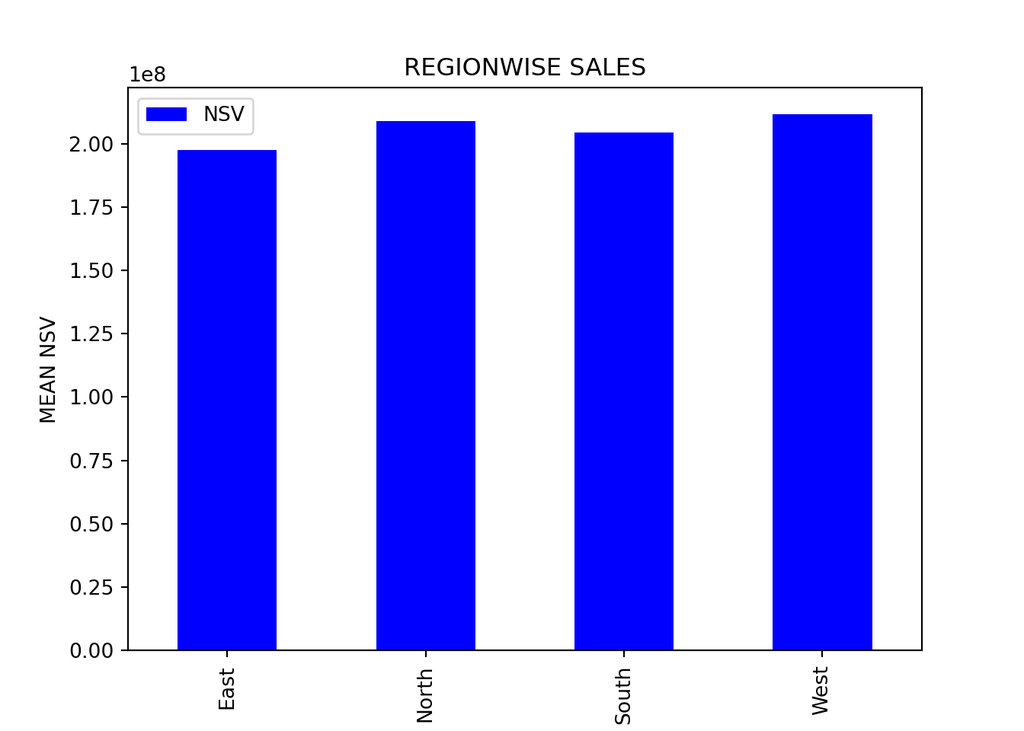

```python
import matplotlib.pyplot as plt
plt.figure();
region_sales.plot.bar('REGION','NSV',title='REGIONWISE SALES', color='blue');
plt.xlabel('REGION'); plt.ylabel('MEAN NSV')
```

#### Objective: Observe the activity of dealers across Months

#### Count number of unique months of transaction for each customers

```python
freq = nsv.groupby('CUSTID')['MONTH'].nunique().reset_index()
freq2 = freq['MONTH'].value_counts().reset_index()
freq2.rename(columns = {'index':'MONTH', 'MONTH':'Freq'}, inplace = True)
freq2.sort_values(by=['MONTH'])
```

```
   MONTH  Freq
2      1  2963
0      2  4181
1      3  3637
3      4  2082
4      5   851
5      6   288
6      7    64
7      8    11
```

#### Most of the customers have transacted in 1-4 months in a year with 2 being highest buying frequency

#### Objective: Get insight on contribution to total sales by each Business Type (Line of Business)

#### Aggregate NSV by BUSINESS

```python
LoB = nsv.groupby('BUSINESS')['NSV'].sum().reset_index()
Tot = sum(LoB['NSV'])
LoB['CONTRI'] = (LoB['NSV']/Tot)*100
LoB
```

```
     BUSINESS        NSV     CONTRI
0       CAKES  324099472  39.439882
1  CHOCOLATES  332482115  40.459972
2    ICECREAM  165174095  20.100146
```

#### Ice Creams contribution is 20% where as cakes and chocolates contribution is 40% each

#### Pie chart for percentage contribution

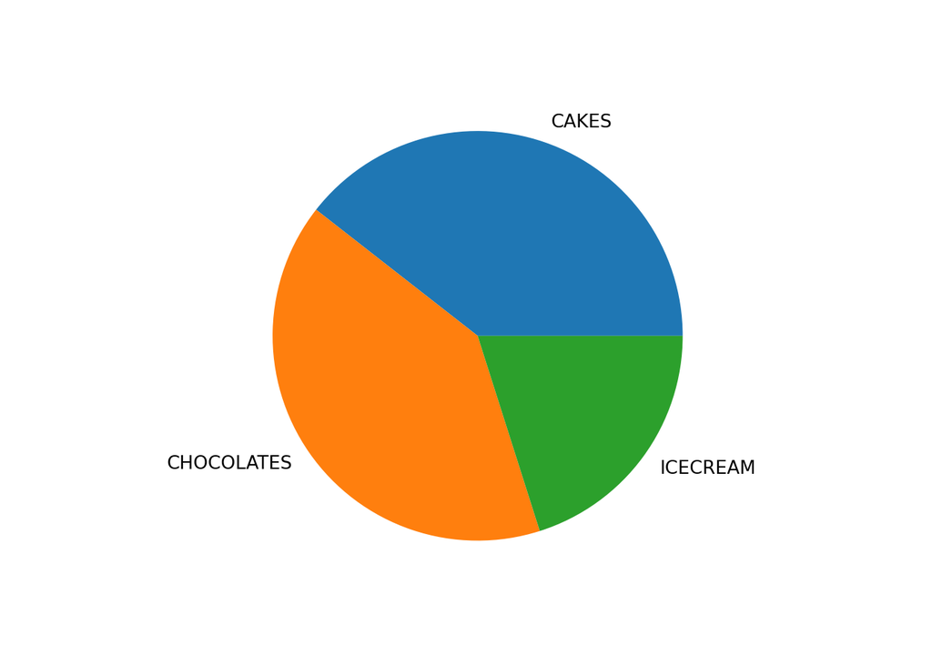

```python
import matplotlib.pyplot as plt
y = np.array(LoB['CONTRI'])
mylabels = LoB['BUSINESS']

plt.pie(y, labels = mylabels);
plt.show()
```

#### Objective: Observe the sales trend across the Year(Month wise Trendline)

#### Aggregate NSV for each month

```python
Month = nsv.groupby('MONTH')['NSV'].sum().reset_index()
```

#### Month wise Trendline

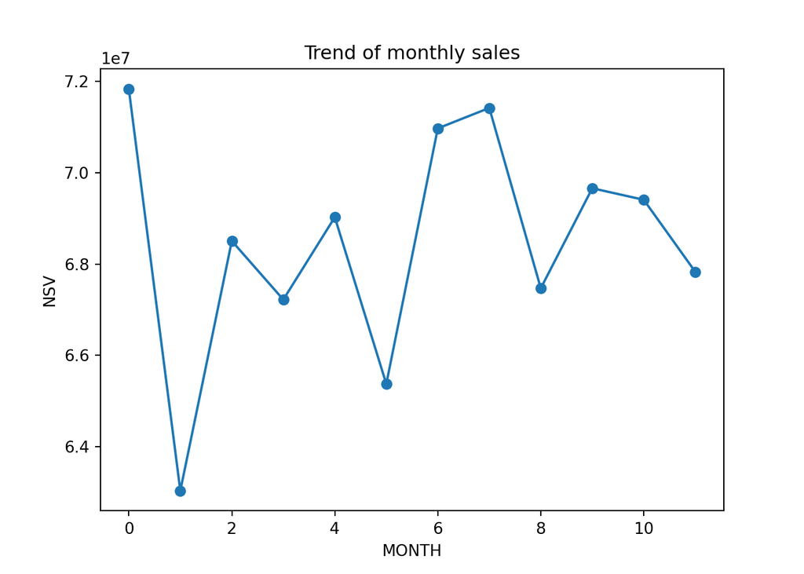

```python
plt.plot(Month['NSV'], marker='o');plt.xlabel('MONTH');plt.ylabel('NSV');plt.title('Trend of monthly sales')
```

#### Objective: Understand Net Promoter Score in each region(Median NPS by Region)

#### Check nps data

```python
nps.head(6)
```

```
   CUSTID  NPS
0   22929    6
1   12089    5
2   19120    6
3   10155    8
4   13085    9
5   14784    4
```

#### Merge ‘nps’ with ‘cust’

```python
nps_reg=pd.merge(nps,cust,how='left')
median_nps = nps_reg.groupby('REGION')['NPS'].median().reset_index()
median_nps
```

```
  REGION  NPS
0   East  6.0
1  North  6.0
2  South  6.0
3   West  7.0
```

#### Median Net Promoter Score is similar across regions

#### Objective: Understand percentage of detractors and promoters in each region

#### Create buckets for NPS using cut function

```python
nps_reg['type'] = pd.cut(nps_reg['NPS'], bins=[-1,6,8,10],labels=["Detractor","Passive","Promoter"])
```

#### Crosstable of region and type using crosstab

```python
pd.crosstab(nps_reg['REGION'],nps_reg['type'])
```

```
type    Detractor  Passive  Promoter
REGION
East           13        5         2
North          13        8         3
South          20       12         3
West           13       13         2
```